# Covid- 19 Pandemic in Switzerland

Dilki Ranasinghe

10/7/2022

**Introduction**

Switzerland is a small mountains country located in Central Europe. This landlocked country is just smaller than the Netherlands or almost twice the size of the US state of New Jersey. It is also bordered by France, Italy, Austria, Germany and Liechtenstein. Berne is the capital of Switzerland. According to the World Happiness Report 2021,the Swiss confederation is officially the third- happiest nation on Earth. Geographically the country is divided into three major regions. Alps cover roughly 58% of the country, the Central Plateau around 31% and the Jura 11%. Switzerland is famous for skiing resorts, lakes, chocolates, cheese and watches. Switzerland is truly a melting pot of various cultures with four official languages. That are German, French, Italian and Romansh. Switzerland’s climate is heavily influenced by the Atlantic Ocean. The current population of Switzerland in 2022 is 8,740,472.Switzerland’s climate is heavily influenced by the Alps as well as by the Atlantic Ocean. Banking and finance are key industries in Switzerland. Switzerland’s universal health care system is highly decentralized, with the cantons or states ,playing a key role in its operation. The system is funded through taxes, social insurance contributions and out-of-pocket payments.

```r
library(tidyverse)
library(magrittr)
```

```
[1] "coronavirus"
```

```
[1] "coronavirus"
```

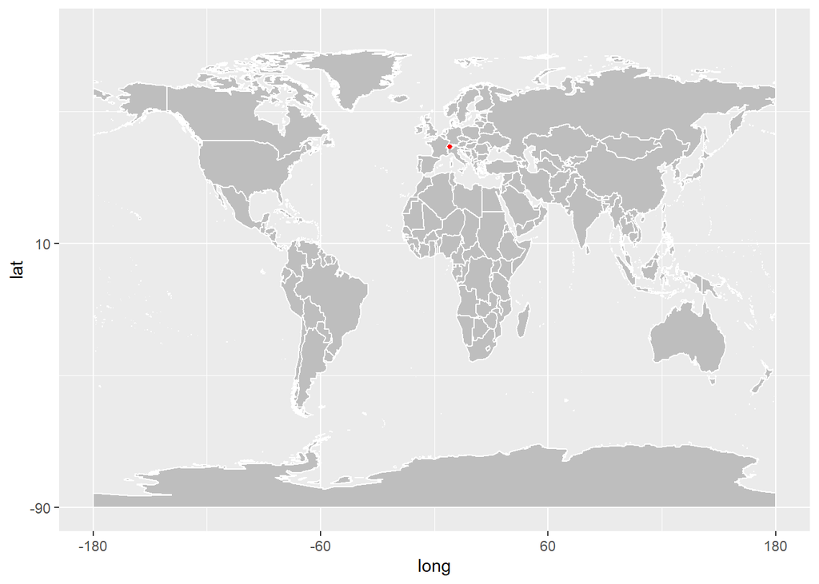

```r
library(ggplot2)
library(plotly)
library(tidyverse)
library(coronavirus)
library(maptools)
library(tibble)
library(ggrepel)
library(png)
library(grid)
library(sp)
```

**Exploratory Data Analysis**

Visualization of death,confirmed,recovered cases

```
      date              province           country               lat
 Min.   :2020-01-22   Length:884         Length:884         Min.   :46.82
 1st Qu.:2020-08-29   Class :character   Class :character   1st Qu.:46.82
 Median :2021-04-07   Mode  :character   Mode  :character   Median :46.82
 Mean   :2021-04-07                                         Mean   :46.82
 3rd Qu.:2021-11-14                                         3rd Qu.:46.82
 Max.   :2022-06-23                                         Max.   :46.82
      long           type               cases            uid
 Min.   :8.227   Length:884         Min.   :    0   Min.   :756
 1st Qu.:8.227   Class :character   1st Qu.:    0   1st Qu.:756
 Median :8.227   Mode  :character   Median :  279   Median :756
 Mean   :8.227                      Mean   : 4216   Mean   :756
 3rd Qu.:8.227                      3rd Qu.: 2690   3rd Qu.:756
 Max.   :8.227                      Max.   :89462   Max.   :756
     iso2               iso3               code3     combined_key
 Length:884         Length:884         Min.   :756   Length:884
 Class :character   Class :character   1st Qu.:756   Class :character
 Mode  :character   Mode  :character   Median :756   Mode  :character
                                       Mean   :756
                                       3rd Qu.:756
                                       Max.   :756
   population      continent_name     continent_code
 Min.   :8654618   Length:884         Length:884
 1st Qu.:8654618   Class :character   Class :character
 Median :8654618   Mode  :character   Mode  :character
 Mean   :8654618
 3rd Qu.:8654618
 Max.   :8654618
```

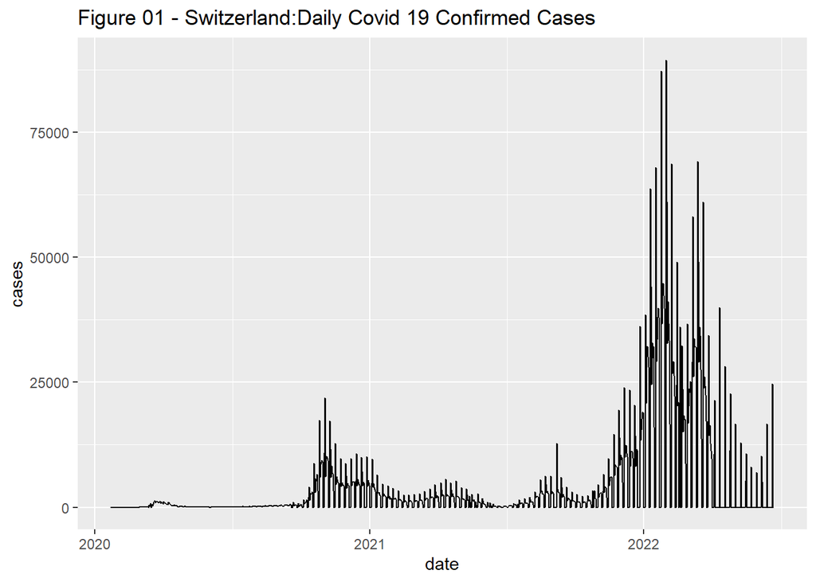

According to the Figure 01,the number of confirmed cases in Switzerland rapidly increased in 2022 than the 2020 and 2021.

```
      date              province           country               lat
 Min.   :2020-01-22   Length:884         Length:884         Min.   :46.82
 1st Qu.:2020-08-29   Class :character   Class :character   1st Qu.:46.82
 Median :2021-04-07   Mode  :character   Mode  :character   Median :46.82
 Mean   :2021-04-07                                         Mean   :46.82
 3rd Qu.:2021-11-14                                         3rd Qu.:46.82
 Max.   :2022-06-23                                         Max.   :46.82
      long           type               cases             uid
 Min.   :8.227   Length:884         Min.   :-87.00   Min.   :756
 1st Qu.:8.227   Class :character   1st Qu.:  1.00   1st Qu.:756
 Median :8.227   Mode  :character   Median :  5.00   Median :756
 Mean   :8.227                      Mean   : 15.64   Mean   :756
 3rd Qu.:8.227                      3rd Qu.: 16.25   3rd Qu.:756
 Max.   :8.227                      Max.   :131.00   Max.   :756
     iso2               iso3               code3     combined_key
 Length:884         Length:884         Min.   :756   Length:884
 Class :character   Class :character   1st Qu.:756   Class :character
 Mode  :character   Mode  :character   Median :756   Mode  :character
                                       Mean   :756
                                       3rd Qu.:756
                                       Max.   :756
   population      continent_name     continent_code
 Min.   :8654618   Length:884         Length:884
 1st Qu.:8654618   Class :character   Class :character
 Median :8654618   Mode  :character   Mode  :character
 Mean   :8654618
 3rd Qu.:8654618
 Max.   :8654618
```

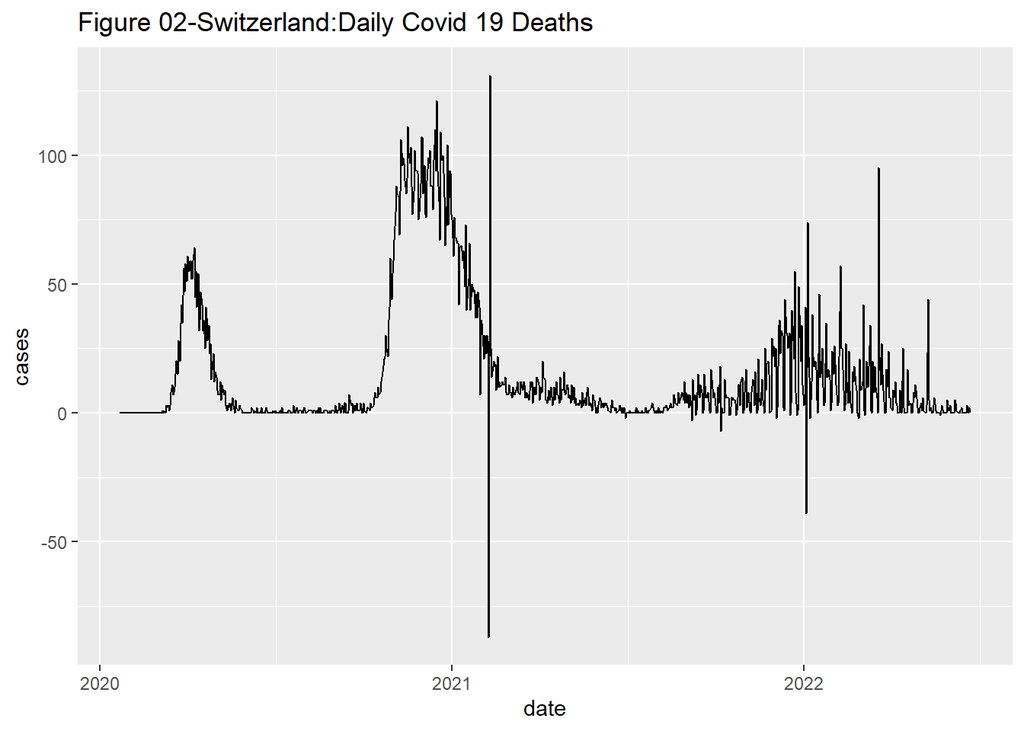

There is an outlier in this dataset.Deaths cannot be a negative value.Therefore removed that value from dataset.

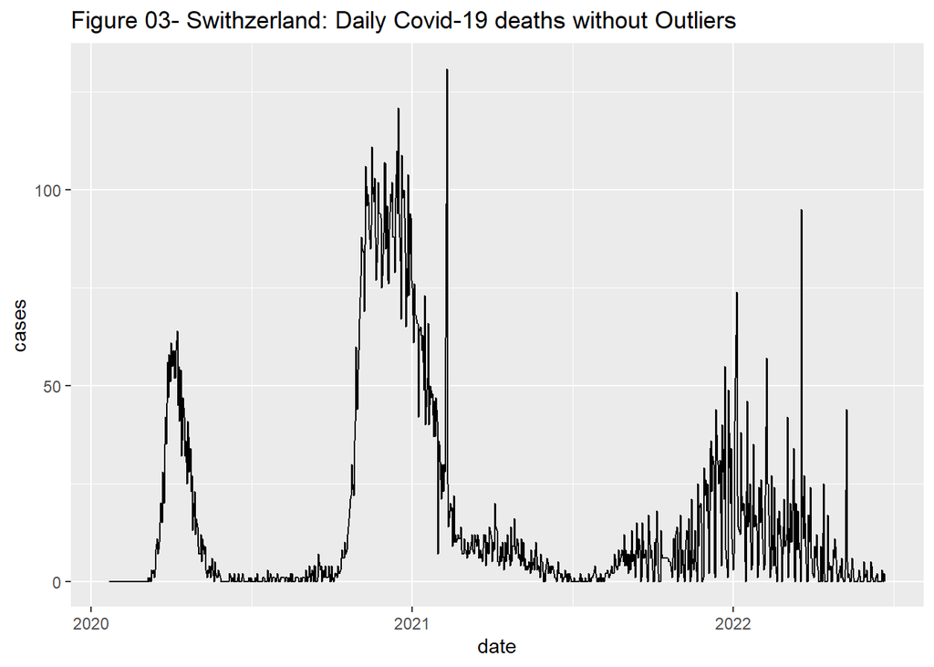

[output not shown]

[figure not shown]

There is an outtlier in this dataset.Recovered cases cannot be zero.Therefore used discontinuity point method.

```
      date              province           country               lat
 Min.   :2020-01-22   Length:884         Length:884         Min.   :46.82
 1st Qu.:2020-08-29   Class :character   Class :character   1st Qu.:46.82
 Median :2021-04-07   Mode  :character   Mode  :character   Median :46.82
 Mean   :2021-04-07                                         Mean   :46.82
 3rd Qu.:2021-11-14                                         3rd Qu.:46.82
 Max.   :2022-06-23                                         Max.   :46.82
      long           type               cases            uid
 Min.   :8.227   Length:884         Min.   :    0   Min.   :756
 1st Qu.:8.227   Class :character   1st Qu.:    0   1st Qu.:756
 Median :8.227   Mode  :character   Median :  279   Median :756
 Mean   :8.227                      Mean   : 4216   Mean   :756
 3rd Qu.:8.227                      3rd Qu.: 2690   3rd Qu.:756
 Max.   :8.227                      Max.   :89462   Max.   :756
     iso2               iso3               code3     combined_key
 Length:884         Length:884         Min.   :756   Length:884
 Class :character   Class :character   1st Qu.:756   Class :character
 Mode  :character   Mode  :character   Median :756   Mode  :character
                                       Mean   :756
                                       3rd Qu.:756
                                       Max.   :756
   population      continent_name     continent_code
 Min.   :8654618   Length:884         Length:884
 1st Qu.:8654618   Class :character   Class :character
 Median :8654618   Mode  :character   Mode  :character
 Mean   :8654618
 3rd Qu.:8654618
 Max.   :8654618
```

[output not shown]

[figure not shown]

[output not shown]

[figure not shown]

There is an outtlier in this dataset.Active cases cannot be zero.Therefore used discontinuity point method.

```
      date              province           country               lat
 Min.   :2020-01-22   Length:884         Length:884         Min.   :46.82
 1st Qu.:2020-08-29   Class :character   Class :character   1st Qu.:46.82
 Median :2021-04-07   Mode  :character   Mode  :character   Median :46.82
 Mean   :2021-04-07                                         Mean   :46.82
 3rd Qu.:2021-11-14                                         3rd Qu.:46.82
 Max.   :2022-06-23                                         Max.   :46.82
      long           type               cases            uid
 Min.   :8.227   Length:884         Min.   :    0   Min.   :756
 1st Qu.:8.227   Class :character   1st Qu.:    0   1st Qu.:756
 Median :8.227   Mode  :character   Median :  279   Median :756
 Mean   :8.227                      Mean   : 4216   Mean   :756
 3rd Qu.:8.227                      3rd Qu.: 2690   3rd Qu.:756
 Max.   :8.227                      Max.   :89462   Max.   :756
     iso2               iso3               code3     combined_key
 Length:884         Length:884         Min.   :756   Length:884
 Class :character   Class :character   1st Qu.:756   Class :character
 Mode  :character   Mode  :character   Median :756   Mode  :character
                                       Mean   :756
                                       3rd Qu.:756
                                       Max.   :756
   population      continent_name     continent_code
 Min.   :8654618   Length:884         Length:884
 1st Qu.:8654618   Class :character   Class :character
 Median :8654618   Mode  :character   Mode  :character
 Mean   :8654618
 3rd Qu.:8654618
 Max.   :8654618
```

[output not shown]

[figure not shown]

comparison with other country

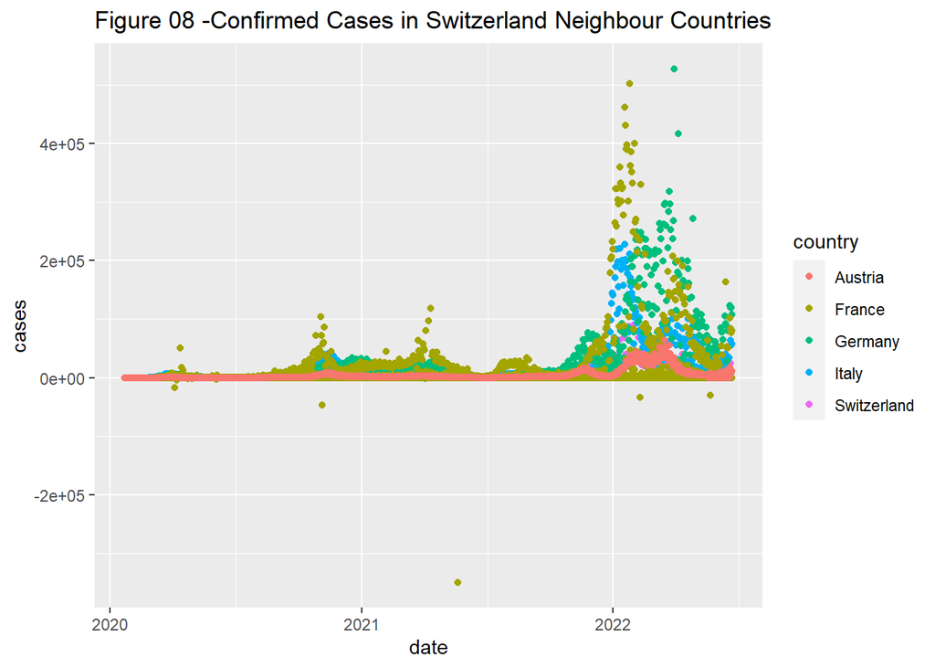

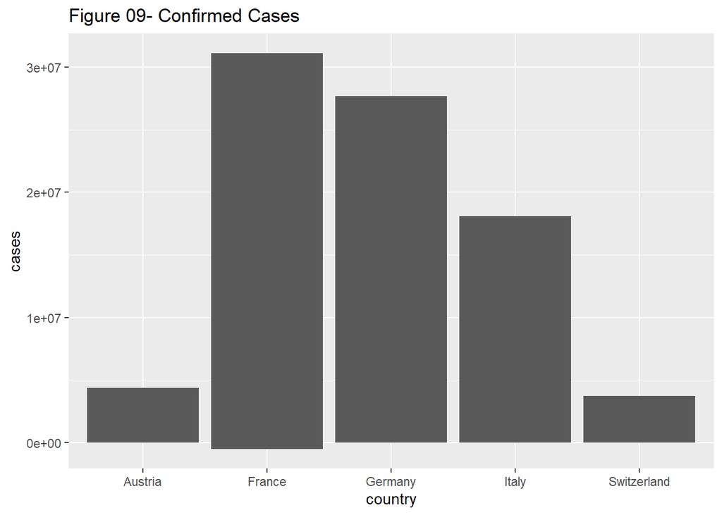

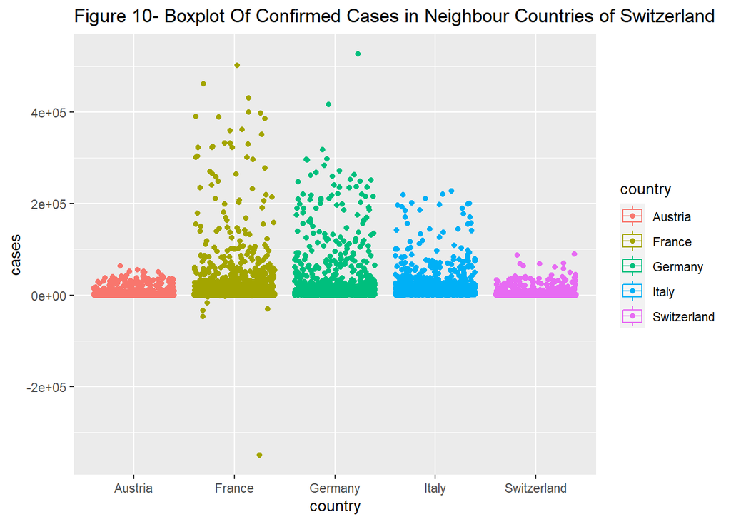

From Figure 08,09,10 Austria have low confirmed coronavirus cases comparied to the other neighbour countries.France, Germany and Italy have more confirmed cases than the Switzerland.

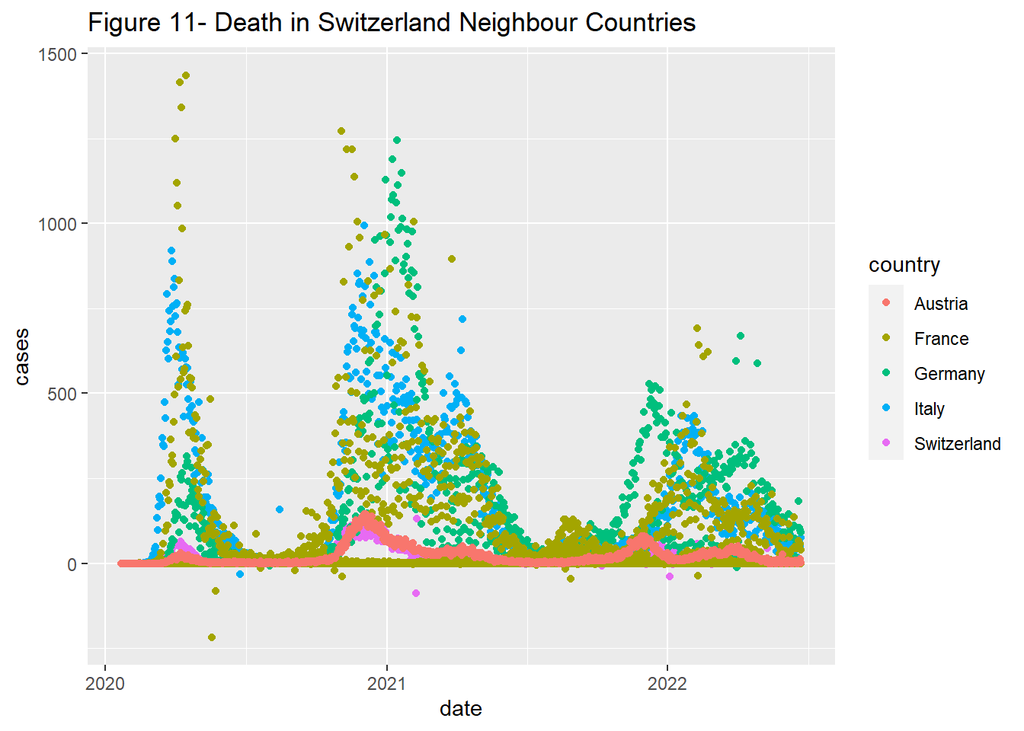

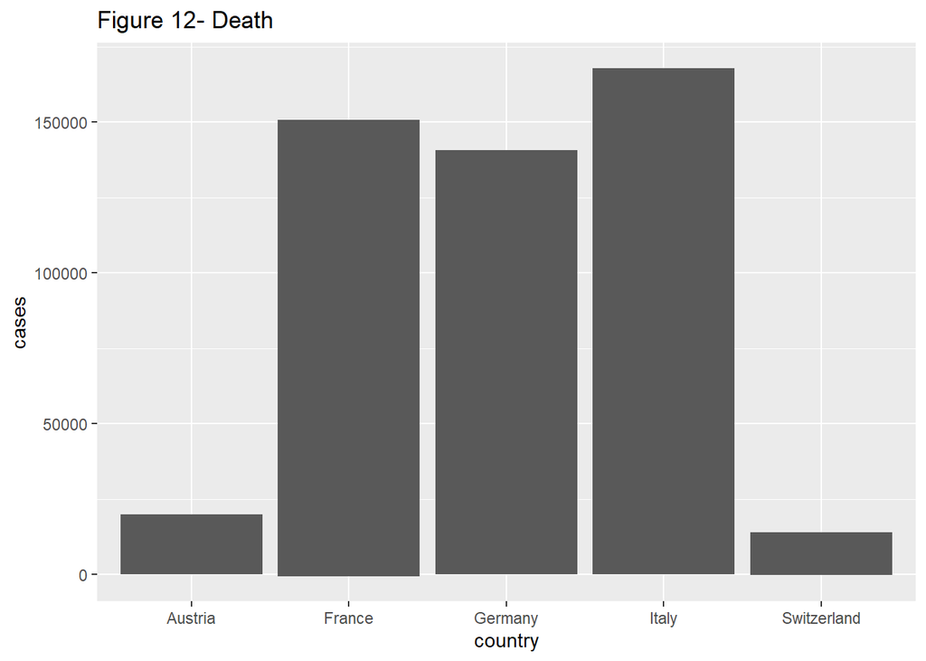

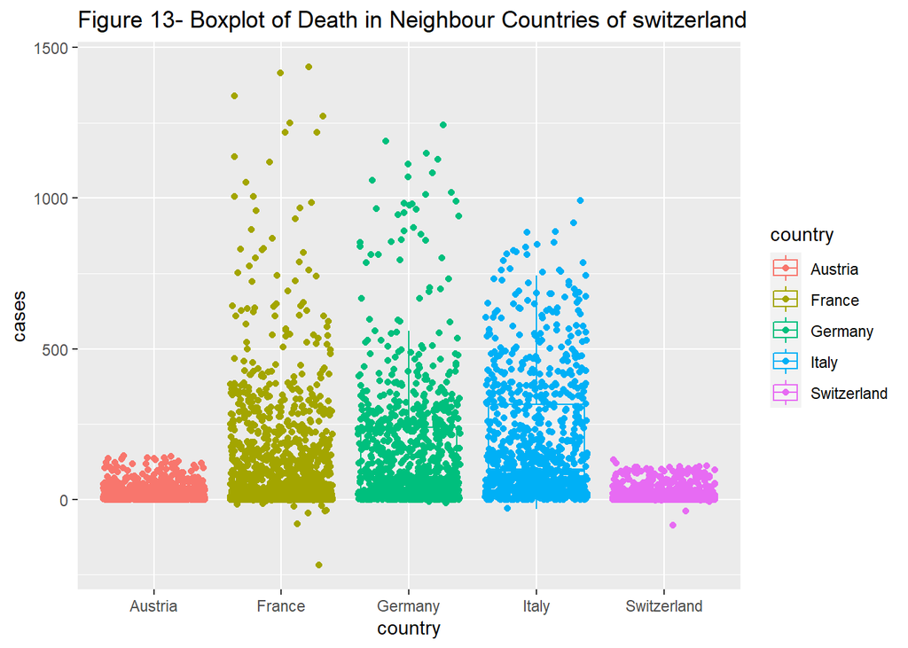

Figure 11,12,13 show the deaths in neighbour countries of Switzerland. Switzerland coronavirus deaths are lower than the other neighbour countries of Switzerland.

**Conclusion and Discussion**

The COVID-19 pandemic in Switzerland is part of the worldwide pandemic of coronavirus disease 2019 (COVID-19) caused by severe acute respiratory syndrome coronavirus 2 (SARS-CoV-2). The virus was confirmed to have spread to Switzerland on 25 February 2020 when the first case of COVID-19 was confirmed following a COVID-19 pandemic in Italy. A 70-year-old man in the Italian-speaking canton of Ticino which borders Italy, tested positive for SARS-CoV-2. The man had previously visited Milan.Afterwards, multiple cases related to the Italy clusters were discovered in multiple cantons, including Basel-City, Zürich, and Graubünden. Multiple isolated cases not related to the Italy clusters were also subsequently confirmed.

On 28 February 2020, the national government, the Federal Council, banned all events with more than 1,000 participants. On 16 March 2020, a State of Extraordinary Situation under the Federal Law of Epidemics was declared. Most shops were closed nationwide. Shortly thereafter, on 20 March, all gatherings of more than five people in public spaces were banned. Additionally, the government gradually imposed restrictions on border crossings and announced economic support measures worth 40 billion Swiss francs. The measures were gradually removed in several phases beginning in late April until June 2020.but new measures were imposed in October as cases surged again.

On 23 December 2020, the vaccination campaign started in Switzerland, ahead of that of most European countries. Four days earlier, Swissmedic approved the first COVID-19 vaccine for regular use. On August 1, 2021, Switzerland achieved a vaccination rate of 52%.[13] From 13 September 2021, access to indoor public spaces like restaurants, bars, museums or fitness centres is only permitted with a valid Covid certificate. Almost all measures were lifted on 17 February 2022.

**References**

*https://en.m.wikipedia.org/wiki/COVID-19_pandemic_in_Switzerland

*https://www.swissinfo.ch/eng/society/covid-19_coronavirus--the-situation-in-switzerland/45592192

*https://covid19.healthdata.org/switzerland?view=cumulative-deaths&tab=trend

*https://graphics.reuters.com/world-coronavirus-tracker-and-maps/countries-and-territories/switzerland/